## **Part 1**

Is rental_raw a tibble? *TRUE*

## **Part 2**

The distribution of values are quite concentrated a living space between 50 up to *180 $m^2$*.

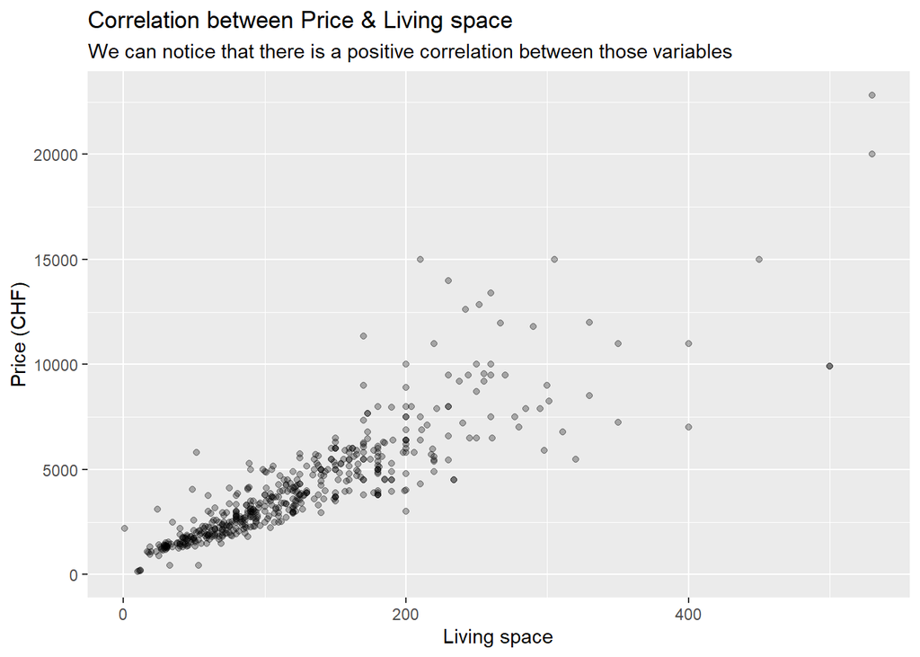

## **Part 3**

We can notice that the top 10 of postcode are between *1200* up to *1209.*

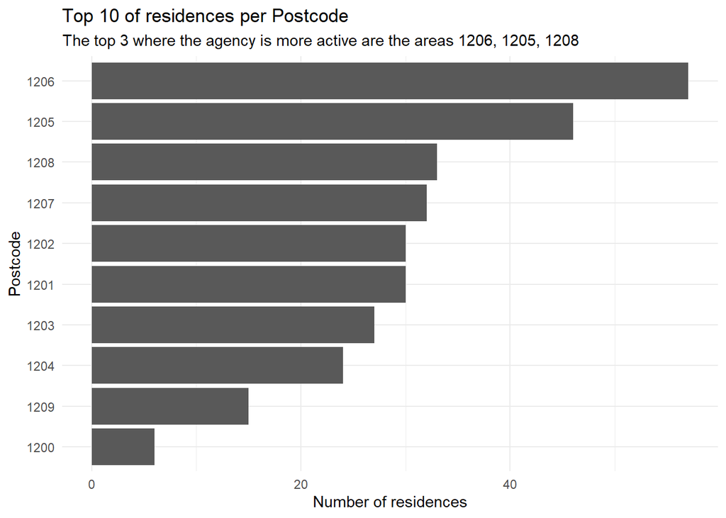

## **Part 4**

Here is a scatterplot that shows the evolution of price with the surface in $m^2$. There is a tile per each floors of our dataset. We can notice that lots of apartments are between the floor *1 to 3*.

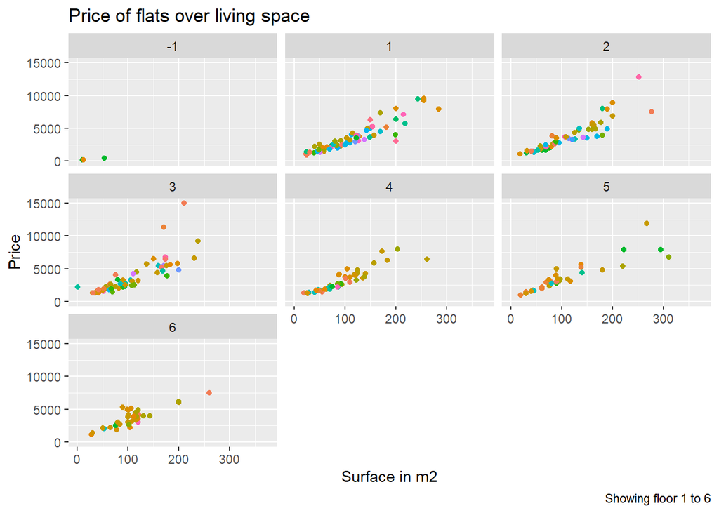

## **Part 5 - Variables comparisons with the attribute Location**

### *Price Comparison*

Price values from *Autres* are less distributed than *sur demande* and it has more outliers. Higher median for sur *demande.*

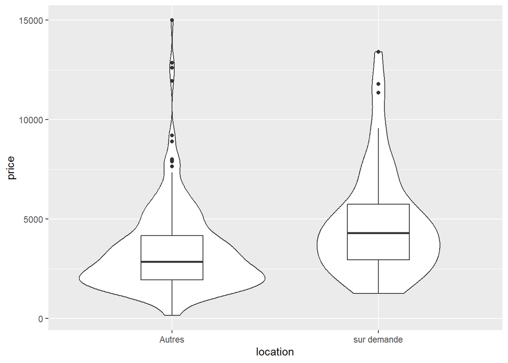

### *Space Comparison*

- Autres: less median
- Sur demande: living space is more concentrated between *100 up to 200 $m^2$*.

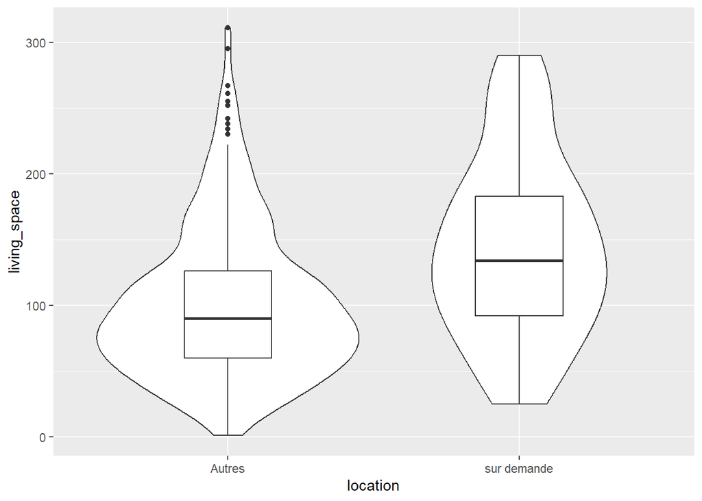

### *Floor Comparison*

- Autres: median are higher than *sur demande*.
- Sur demande: floors seems less higher than *Autres*.

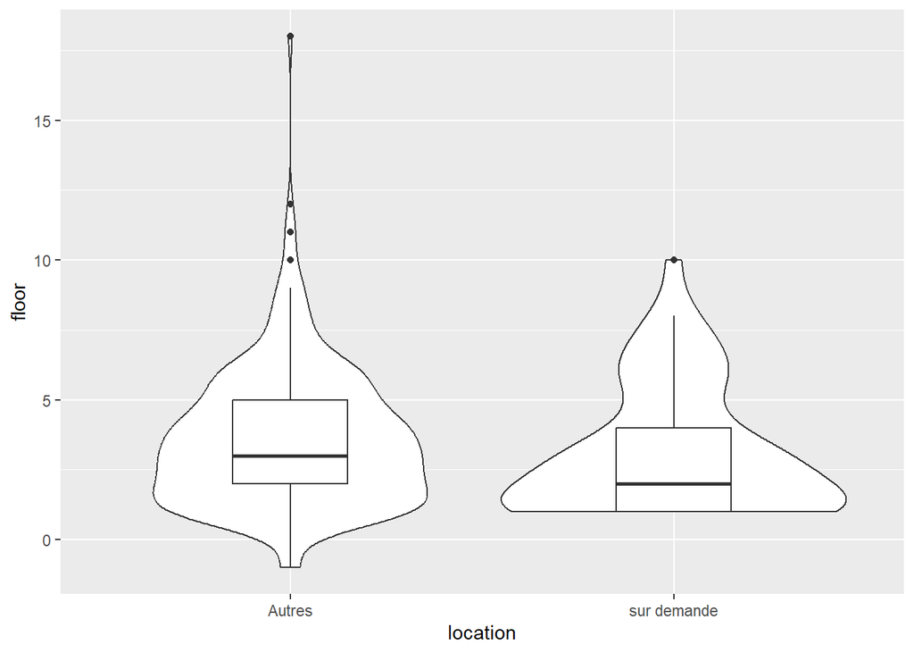

## **Part 6 - Descriptive Analysis**

There is a clear outlier on *Autres*.

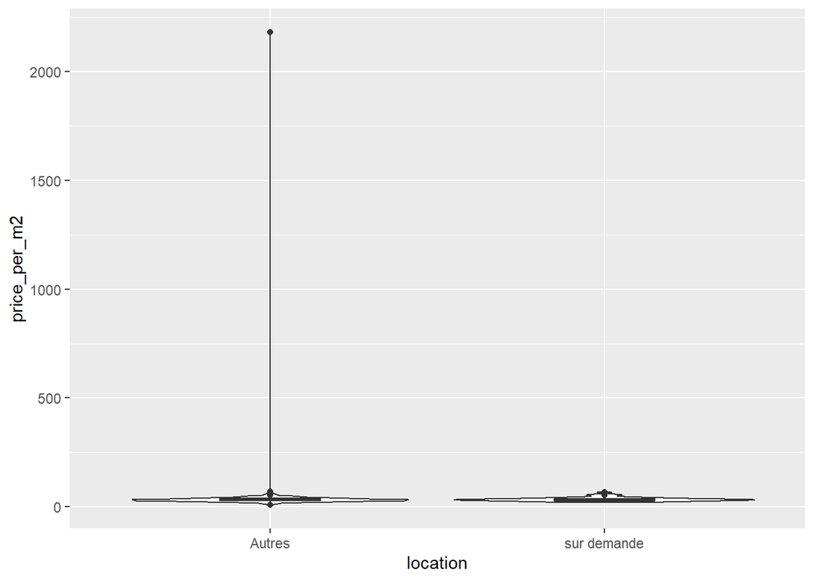

| location | group_size | median_price | median_p_m2 | median_space | mean_price | mean_p_m2 | mean_space | sd_price | sd_p_m2 | sd_space | sd_floor | min_price_m2 | max_price_m2 |
| --- | --- | --- | --- | --- | --- | --- | --- | --- | --- | --- | --- | --- | --- |
| Autres | 275 | 2850 | 33.12500 | 90 | 3389.171 | 34.14916 | 101.2873 | 2127.226 | 8.690432 | 56.96703 | 2.472581 | 8.301887 | 71.42857 |
| sur demande | 53 | 4300 | 32.35294 | 134 | 4785.170 | 33.81902 | 144.6038 | 2708.427 | 9.252490 | 69.03994 | 2.347373 | 19.230769 | 66.76471 |

Thanks to the boxplot we can notice an outlier for the label *Autres* which has a price above *2000.-CHF/$m^2$*. This outlier impact our analysis then we have to delete it.

Now, if we compare both samples from the table above we can generally notice the number of observations between the locations Autres, sur demande are not equal at all. Indeed, the number of observations of a test are pretty important because the more you have observations, the more your the statistical tests are stronger.

Then the observations from Autres, sur demande with n = to 275, 53, I believe the descriptive test for the label *Autres* are stronger than *Sur demande*.

The sd_price for Autres, sur demande shows us that prices from *sur demande* are more spread.

is shows price for flats with the label *sur demande* are widely spread rather than *Autres*. The median and mean price is more elevated for flats *sur demande*.

| Stats | Median Price | Mean Price |
| --- | --- | --- |
| Autres | 2850 CHF | 3389.17 CHF |
| sur demande | 4300 CHF | 4785.17 CHF |

## **Part 6 - T-Test Analysis**

| statistic | t_df | p_value | alternative | estimate | lower_ci | upper_ci |
| --- | --- | --- | --- | --- | --- | --- |
| 0.2401512 | 70.79724 | 0.8109071 | two.sided | 0.3301435 | -2.41113 | 3.071417 |

*Hypothesis:*

- H0: the average *price per square-meter* for the flats Autres, sur demande are equal.
- H1: the average *price per square-meter* for the flats Autres, sur demande are different.

## **Part 7**

*Hypothesis:*

- H0: the average *price* for the flats Autres, sur demande are equal.
- H1: the average *price* for the flats Autres, sur demande are different.

| statistic | t_df | p_value | alternative | estimate | lower_ci | upper_ci |
| --- | --- | --- | --- | --- | --- | --- |
| -3.547421 | 64.92512 | 0.0007284 | two.sided | -1395.999 | -2181.94 | -610.058 |

*Results:*

The t-test affirms that the average *price* for flats Autres, sur demande are different because the p-value is 7.2836571^{-4} (less than 0.05). Then we can affirm that our t-test is correct and we can reject H0.

**Compare the results of price per square meter with those for price. Are there differences between the results?**

| location | mean_price | median_price | sd_price | mean_p_m2 | median_p_m2 | sd_p_m2 |
| --- | --- | --- | --- | --- | --- | --- |
| Autres | 3389.171 | 2850 | 2127.226 | 34.14916 | 33.12500 | 8.690432 |
| sur demande | 4785.170 | 4300 | 2708.427 | 33.81902 | 32.35294 | 9.252490 |

## **Part 8**

Here is a bunch of 30 addresses from the rental agency:

[interactive chart not shown]